# Analytic GRIM-U: A granularity consistency test for Mann-Whitney U-test *p* values

30 January, 2026

```r
library(tidyverse)
library(patchwork)
library(viridisLite)
library(analyticgrimu)

my_colors <- viridis(n = 2, begin = 0.3, end = 0.7)
```

# Methodological Description

The Analytic GRIM-U Test

The Granularity-Related Inconsistency of Mann-Whitney U (GRIM-U) test evaluates the mathematical consistency between reported sample sizes ($n_1, n_2$), the test statistic ($U$), and the reported $p$-value ($p_{rep}$).

The method relies on the property that the Mann-Whitney $U$ statistic is discrete (granular), defined on a lattice of integers or half-integers, rather than a continuous scale. Consequently, for any fixed pair of sample sizes, only a finite set of $p$-values can be generated.The Analytic GRIM-U algorithm, implemented in R, performs a forensic consistency check through a four-step process: (1) defining the search space via inverse probability mapping, (2) generating a lattice of candidate $U$ statistics, (3) computing corresponding $p$-values using multiple standard approximation methods, and (4) verifying consistency against reported rounding precision.

## 1. The Domain of the Test Statistic

For two independent samples of size $n_1$ and $n_2$, the Mann-Whitney $U$ statistic is bounded by

$$[0, n_1 n_2]$$

Unlike continuous statistics, $U$ must strictly adhere to a lattice structure:Case A (No Ties): $U$ must be an integer ($U \in \mathbb{Z}$).Case B (Ties): $U$ may be a half-integer ($U \in \{x \mid 2x \in \mathbb{Z}\}$).The algorithm checks if a specific reported $U_{rep}$ (if available) satisfies these granularity and boundary constraints. If $U_{rep}$ is not reported, the algorithm searches for any valid $U$ that could produce $p_{rep}$.

## 2. Inverse Mapping and Search Window

To avoid an exhaustive search of the entire sampling distribution (which becomes computationally expensive as $N$ increases), the algorithm defines a “Candidate Window” of possible $U$ values by inverting the normal approximation.

First, a range of plausible probability values $[p_{min}, p_{max}]$ is established based on the reported precision of $p_{rep}$ (e.g., a $p$-value reported as .05 implies a range of roughly $[.045, .055]$ under standard rounding, or $[.050, .060]$ under truncation).

These boundary probabilities are converted into $Z$-scores ($Z_{min}, Z_{max}$) using the inverse cumulative distribution function of the standard normal distribution ($\Phi^{-1}$). The corresponding bounds for $U$ are estimated using the asymptotic moments of the distribution:

$$\mu_U = \frac{n_1 n_2}{2}$$

$$\sigma_{U} = \sqrt{\frac{n_1 n_2 (N + 1)}{12}}$$

The estimated candidate range $[U_{start}, U_{end}]$ is calculated as:

$$U_{bound} = \mu_U \pm Z_{bound} \cdot \sigma_U$$

To account for approximation errors and the discrete nature of the exact distribution, this range is padded by a buffer (default $\pm 2$ units) and clamped to the physical bounds $[0, n_1 n_2]$.

## 3. Candidate Generation and P-Value Reconstruction

The algorithm generates a grid of all valid integers and half-integers within the candidate range $[U_{start}, U_{end}]$. For every candidate $U$ in this grid, the algorithm calculates five distinct theoretical $p$-values to account for variations in statistical software implementation and data characteristics (specifically, the presence of ties and continuity corrections).

A. Exact Method:Calculated using the recursive properties of the Wilcoxon distribution (pwilcox in R). This is computed only when the candidate $U$ is an integer. B. Asymptotic Approximation (Normal Approximation):

Four variations of the $Z$-statistic are computed for every candidate $U$. The general form is:

$$Z = \frac{U - \mu_U - \delta_{cc}}{\sigma_{est}}$$

where $\delta_{cc}$ represents the continuity correction.

It is $0.5$ (subtracted from the absolute deviation from the mean) if applied, and $0$ otherwise.$\sigma_{est}$ is the standard error, which varies based on the assumption of tied ranks.

The algorithm implements the following four asymptotic variants:

- Uncorrected, No Ties: $\delta_{cc} = 0$, using $\sigma_{no\_ties}$.
- Corrected, No Ties: $\delta_{cc} = 0.5$, using $\sigma_{no\_ties}$.
- Uncorrected, Ties: $\delta_{cc} = 0$, using $\sigma_{ties}$.
- Corrected, Ties: $\delta_{cc} = 0.5$, using $\sigma_{ties}$.

Note on Ties Variance: To test if any configuration of ties could yield the reported value, the algorithm calculates $\sigma_{ties}$ assuming the minimal possible variance reduction (a single pair of tied ranks). This provides a conservative “existence proof”—if the reported $p$ is consistent with this minimal-tie variance, it is flagged as potentially consistent via the “Ties” pathway. The variance adjustment is:

$$\sigma_{ties} = \sqrt{\sigma_{noties}^2 - \frac{n_1 n_2}{2 N (N-1)}}$$

## 4. Consistency Verdict

For a reported result to be considered consistent, there must exist at least one candidate $U$ in the search window such that at least one of the five calculated $p$-values rounds or truncates to the reported $p_{rep}$.

The method supports multiple rounding standards (standard round-half-up, truncation, and ceiling) to prevent false positives due to rounding ambiguity. If no candidate $U$ produces a matching $p$-value across any of the five calculatory methods, the reported result is flagged as mathematically inconsistent with the given sample sizes.

# Illustrating granularity in U-test p values

NOTE THAT THIS IS ONLY FOR THE EXACT TEST WITH NO TIES, NOT FOR TIES OR ASYPTOTIC P VALUES

## Long format plot

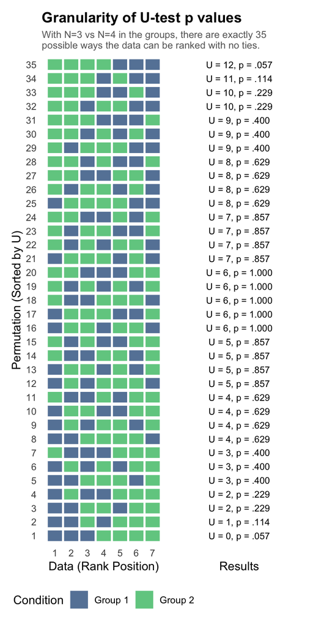

```r
# --- 1. Generate All Permutations (The "Universe" of Possibilities) ---
# We use N=3 vs N=3 because 20 combinations is perfect for a single slide/plot.
n1 <- 3
n2 <- 4
N_total <- n1 + n2

# Generate all possible rank positions for Group 1
# combn returns a matrix where each column is a set of ranks for Group 1
rank_combinations <- combn(1:N_total, n1, simplify = FALSE)

# Process into a tidy format
possibilities <- tibble(
  perm_id = seq_along(rank_combinations),
  ranks_g1 = rank_combinations
) %>%
  rowwise() %>%
  mutate(
    # Calculate U for Group 1: Sum(Ranks) - n(n+1)/2
    sum_ranks = sum(ranks_g1),
    U = sum_ranks - (n1 * (n1 + 1) / 2),

    # Calculate Exact P-value (Two-sided)
    p_value = wilcox.test(x = ranks_g1, y = setdiff(1:N_total, ranks_g1))$p.value
  ) %>%
  ungroup() %>%
  # Sort by U so the plot looks organized (Perfect separation -> Mixed)
  arrange(U) %>%
  mutate(perm_id = factor(perm_id, levels = perm_id)) |>
  mutate(y_label = as.factor(row_number()))

# Expand for the "Strip Plot" (Barcode view)
# We need a row for every rank position (1 to 6) for every permutation
plot_data <- possibilities %>%
  mutate(
    rank_pos = list(1:N_total),
    # map2 returns a list naturally, which fits into the list-column
    group_at_rank = map2(rank_pos, ranks_g1, ~ ifelse(.x %in% .y, "Group 1", "Group 2"))
  ) %>%
  unnest(cols = c(rank_pos, group_at_rank))

# --- 2. Create the Visualizations ---

# Plot A: The Permutations (Visualizing the "Ranks")
p_ranks <- ggplot(plot_data, aes(x = rank_pos, y = y_label, fill = group_at_rank)) +
  geom_tile(color = "white", width = 0.9, height = 0.8, alpha = 0.8) +
  #scale_fill_manual(values = c("Group 1" = "#4477AA", "Group 2" = "#BBCC33")) +
  scale_fill_manual(values = c("Group 1" = my_colors[1], "Group 2" = my_colors[2])) +
  scale_x_continuous(breaks = 1:N_total, name = "Data (Rank Position)") +
  labs(
    title = "Granularity of U-test p values",
    subtitle = paste0("With N=", n1, " vs N=", n2, " in the groups, there are exactly ", nrow(possibilities), "\npossible ways the data can be ranked with no ties."),
    y = "Permutation (Sorted by U)",
    fill = "Condition"
  ) +
  theme_minimal() +
  theme(
    plot.title = element_text(face = "bold", margin = margin(b=5)),
    plot.subtitle = element_text(size = 9, color = "gray40"),
    strip.text = element_blank(),

    # Strictly remove all grid lines
    panel.grid = element_blank(),
    panel.grid.major = element_blank(),
    panel.grid.minor = element_blank(),

    # Remove axis ticks and lines for a cleaner look
    axis.ticks = element_blank(),
    axis.line = element_blank(),

    # # Keep X axis text, hide Y axis text
    # axis.text.y = element_blank(),
    legend.position = "bottom"
  )

# Plot B: The Granularity (Visualizing the U and P)
# We highlight the discrete nature of U and P
p_stats <- possibilities %>%
  ggplot(aes(y = perm_id)) +
  # Connect U and P visually
  #geom_segment(aes(x = 0, xend = 1, y = perm_id, yend = perm_id), color = "white", linewidth = 5.5) +

  # # Plot the U value
  # geom_text(aes(x = 0.2, label = paste0("U = ", U)), color = "gray30", fontface = "bold", size = 5) +

  # Plot the P value
  # geom_label(aes(x = 0.8, label = sprintf("p = %.3f", p_value),
  #                fill = factor(p_value)),
  #            color = "white", size = 4.5, show.legend = FALSE) +
  #
  # geom_label(aes(x = 0.2, label = paste0("U = ", U),
  #                fill = factor(p_value)),
  #            color = "white", size = 4.5, show.legend = FALSE) +

  # geom_label(aes(x = 0.5,
  #                label = sprintf("U = %s, p = %.3f", U, p_value),
  #                fill = factor(p_value)),
  #            color = "white", size = 4.5, fontface = "bold", show.legend = FALSE) +

  geom_text(aes(
    x = 0.15,
    label = sprintf("U = %s, p = %s", U, sub("^0", "", sprintf("%.3f", p_value)))
  ),
  size = 3,
  #fontface = "bold",
  show.legend = FALSE) +

  scale_fill_viridis_d(option = "magma", end = 0.8) +
  scale_x_continuous(limits = c(0, 0.3), name = "Results") +
  labs(
    # title = "Results",
    # subtitle = paste0("Only some U and p values are possible."),
    y = NULL
  ) +
  theme_minimal() +
  theme(
    plot.title = element_text(face = "bold", margin = margin(b=5)),
    plot.subtitle = element_text(size = 9, color = "gray40"),
    strip.text = element_blank(),
    panel.grid = element_blank(),
    axis.text = element_blank(),
    axis.ticks = element_blank(),
    #axis.title = element_blank(),  # Hides "Resulting Statistics" to match your void look
    panel.border = element_blank()
  )

# Combine
final_plot <- p_ranks + p_stats +
  plot_layout(widths = c(1, 1))


final_plot
```

## Wide format plot

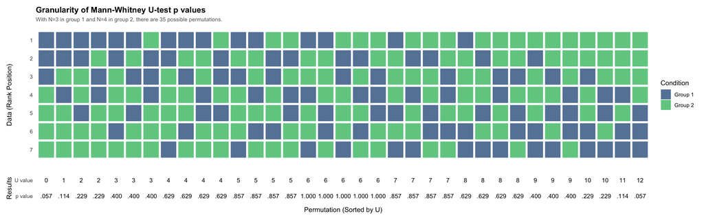

```r
# --- 1. Generate Data (Unchanged) ---
n1 <- 3
n2 <- 4
N_total <- n1 + n2
rank_combinations <- combn(1:N_total, n1, simplify = FALSE)

possibilities <- tibble(
  perm_id = seq_along(rank_combinations),
  ranks_g1 = rank_combinations
) %>%
  rowwise() %>%
  mutate(
    sum_ranks = sum(ranks_g1),
    U = sum_ranks - (n1 * (n1 + 1) / 2),
    p_value = wilcox.test(x = ranks_g1, y = setdiff(1:N_total, ranks_g1))$p.value
  ) %>%
  ungroup() %>%
  arrange(U) %>%
  mutate(perm_id = factor(perm_id, levels = perm_id))



plot_data <- possibilities %>%
  mutate(
    rank_pos = list(1:N_total),
    group_at_rank = map2(rank_pos, ranks_g1, ~ ifelse(.x %in% .y, "Group 1", "Group 2"))
  ) %>%
  unnest(cols = c(rank_pos, group_at_rank))

# --- 2. Create the Visualizations (Corrected) ---

# Plot A: The Permutations
# X = Permutation, Y = Rank Position
p_ranks <- ggplot(plot_data, aes(x = perm_id, y = rank_pos, fill = group_at_rank)) +
  geom_tile(color = "white", width = 0.9, height = 0.9, alpha = 0.8) +
  scale_fill_manual(values = c("Group 1" = my_colors[1], "Group 2" = my_colors[2])) +

  # FIX: Rank position is now on the Y axis, so we use scale_y_continuous
  scale_y_reverse(breaks = 1:N_total, name = "Data (Rank Position)") +

  labs(
    title = "Granularity of Mann-Whitney U-test p values",
    subtitle = paste0("With N=", n1, " in group 1 and N=", n2, " in group 2, there are ", nrow(possibilities), " possible permutations."),
    x = NULL, # Hide X label to merge with bottom plot
    fill = "Condition"
  ) +
  theme_minimal() +
  theme(
    plot.title = element_text(face = "bold", margin = margin(b=5)),
    plot.subtitle = element_text(size = 9, color = "gray40"),
    strip.text = element_blank(),
    panel.grid = element_blank(),
    axis.ticks = element_blank(),
    axis.line = element_blank(),
    # We hide the X axis text because it will be shared with the bottom plot
    axis.text.x = element_blank(),
    legend.position = "right"
  )
#coord_fixed(ratio = 1)

# Plot B: The Granularity
# X = Permutation (Must match plot A)
p_stats <- possibilities %>%
  ggplot(aes(x = perm_id)) +

  # Stacked Labels
  # geom_label(aes(
  #   y = 0.25,
  #   fill = factor(p_value),
  #   label = sprintf("%.3f", p_value)
  # ),
  # color = "white",
  # size = 3.5, fontface = "bold", show.legend = FALSE) +
  #
  # geom_label(aes(
  #   y = 0.75,
  #   fill = factor(p_value),
  #   label = U
  # ),
  # color = "white",
  # size = 3.5, fontface = "bold", show.legend = FALSE) +

  geom_text(aes(
    y = 0.25,
    label = sub("^0", "", sprintf("%.3f", p_value))
  ),
  size = 3.5,
  #fontface = "bold",
  show.legend = FALSE) +

  geom_text(aes(
    y = 0.75,
    label = U
  ),
  size = 3.5,
  #fontface = "bold",
  show.legend = FALSE) +

  # scale_fill_viridis_d(option = "magma", end = 0.8) +

  # CHANGE 1: Define breaks at the exact heights of your labels (0.25 and 0.75)
  # and assign the labels "p" and "U" to them.
  scale_y_continuous(limits = c(0, 1),
                     breaks = c(0.25, 0.75),
                     labels = c("p value", "U value")) +
  labs(
    title = NULL,
    x = "Permutation (Sorted by U)",
    y = "Results"
  ) +
  theme_minimal() +
  theme(
    panel.grid = element_blank(),

    # # CHANGE 2: Enable the Y-axis text so "U" and "p" are visible
    # axis.text.y = element_text(),
    axis.text.x = element_blank(),

    axis.ticks = element_blank(),
    panel.border = element_blank()
  )

# --- 3. Combine ---
final_plot <- p_ranks / p_stats +
  plot_layout(heights = c(4, 1))

print(final_plot)
```

# Illustrate how possible p values increases with N

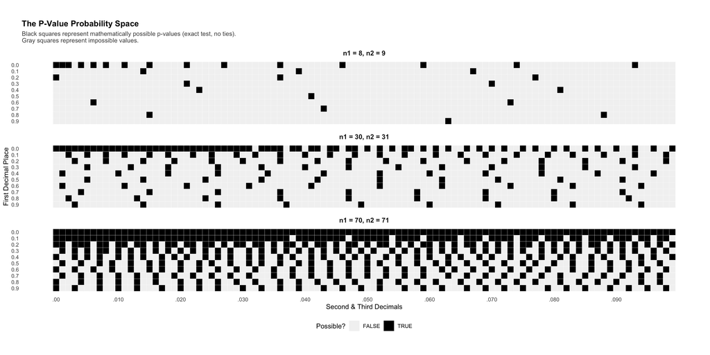

```r
analyticgrimu::plot_grimu_probability(n1_vec = c(8, 30, 70), n2_vec = c(9, 31, 71))
```